# Part I - PISA 2022 Dataset Exploration

## Introduction

The Programme for International Student Assessment (PISA) is one of the most comprehensive international assessments of student learning outcomes, evaluating education systems worldwide by testing the skills and knowledge of 15-year-old students. This notebook explores the PISA 2022 dataset, which contains data from approximately 600,000 students across participating countries.

PISA assessments focus on three core domains: mathematics, reading, and science. Beyond academic performance, PISA collects extensive contextual information about students' socioeconomic backgrounds, attitudes toward learning, and school environment. This rich dataset allows researchers and policymakers to examine factors that influence student achievement across different educational systems.

This exploration aims to uncover patterns and relationships in student performance, with particular attention to:

- Country-level differences in academic achievement
- Gender gaps across different subject domains
- The impact of socioeconomic status on performance
- The interplay between school climate and academic outcomes

## Preliminary Wrangling

```python
# import all packages and set plots to be embedded inline
import numpy as np
import pandas as pd
import matplotlib.pyplot as plt
import seaborn as sns
import gc
import os
from scipy import stats
import warnings
```

```python
os.makedirs('outputs/plots', exist_ok=True)
# warnings.simplefilter("ignore")

# Load the optimized dataset
student_df = pd.read_csv("dataset/pisa.csv")
print(f"Dataset shape: {student_df.shape}")
```

```
Dataset shape: (613744, 1278)
```

```python
student_df.head()
```

|  | CNT | CNTRYID | CNTSCHID | CNTSTUID | CYC | NatCen | STRATUM | SUBNATIO | REGION | OECD | ... | PV3MPRE | PV4MPRE | PV5MPRE | PV6MPRE | PV7MPRE | PV8MPRE | PV9MPRE | PV10MPRE | SENWT | VER_DAT |
| --- | --- | --- | --- | --- | --- | --- | --- | --- | --- | --- | --- | --- | --- | --- | --- | --- | --- | --- | --- | --- | --- |
| 0 | ALB | 8.0 | 800282.0 | 800001.0 | 08MS | 800 | ALB03 | 80000 | 800.0 | 0.0 | ... | 226.250 | 203.029 | 219.817 | 331.017 | 223.752 | 305.671 | 230.156 | 289.436 | 0.55561 | 03MAY23:10:11:25 |
| 1 | ALB | 8.0 | 800115.0 | 800002.0 | 08MS | 800 | ALB03 | 80000 | 800.0 | 0.0 | ... | 298.644 | 321.405 | 320.452 | 284.836 | 364.565 | 304.044 | 347.626 | 352.269 | 0.76431 | 03MAY23:10:11:25 |
| 2 | ALB | 8.0 | 800242.0 | 800003.0 | 08MS | 800 | ALB01 | 80000 | 800.0 | 0.0 | ... | 383.340 | 376.019 | 285.901 | 289.896 | 338.469 | 316.296 | 324.361 | 343.351 | 1.37877 | 03MAY23:10:11:25 |
| 3 | ALB | 8.0 | 800245.0 | 800005.0 | 08MS | 800 | ALB08 | 80000 | 800.0 | 0.0 | ... | 264.532 | 303.422 | 327.793 | 165.575 | 246.156 | 238.322 | 275.860 | 227.466 | 1.49361 | 03MAY23:10:11:26 |
| 4 | ALB | 8.0 | 800285.0 | 800006.0 | 08MS | 800 | ALB03 | 80000 | 800.0 | 0.0 | ... | 399.300 | 514.739 | 539.850 | 461.793 | 514.465 | 510.462 | 490.537 | 503.793 | 0.65249 | 03MAY23:10:11:26 |

5 rows × 1278 columns

```python
student_df.describe().to_csv("outputs/pisa_describe.csv")
student_df.describe().info()
```

```
<class 'pandas.core.frame.DataFrame'>
Index: 8 entries, count to max
Columns: 1274 entries, CNTRYID to SENWT
dtypes: float64(1274)
memory usage: 79.7+ KB
```

### Memory Optimization Functions

```python
def memory_usage(pandas_obj):
    """Calculate memory usage of a pandas object in MB"""
    if isinstance(pandas_obj, pd.DataFrame):
        usage_bytes = pandas_obj.memory_usage(deep=True).sum()
    else:  # Series
        usage_bytes = pandas_obj.memory_usage(deep=True)
    usage_mb = usage_bytes / (1024 * 1024)
    return usage_mb
```

```python
def optimize_floats(df):
    """Optimize float dtypes by downcasting to float32 where possible"""
    float_cols = df.select_dtypes(include=['float64']).columns

    for col in float_cols:
        # Check if column can be represented as float32 without losing precision
        df[col] = pd.to_numeric(df[col], downcast='float')

    return df
```

```python
def optimize_ints(df):
    """Optimize integer dtypes by downcasting to smallest possible integer type"""
    int_cols = df.select_dtypes(include=['int64']).columns

    for col in int_cols:
        # For each column, downcast to the smallest possible integer type
        df[col] = pd.to_numeric(df[col], downcast='integer')

    return df
```

```python
def optimize_categorical(df, categorical_threshold=0.5, excluded_cols=None):
    """Convert columns with low cardinality to categorical type"""
    if excluded_cols is None:
        excluded_cols = []

    # Identify columns that are good candidates for categorical conversion
    obj_cols = df.select_dtypes(include=['object']).columns
    for col in obj_cols:
        if col not in excluded_cols:
            num_unique_values = len(df[col].unique())
            num_total_values = len(df[col])
            if num_unique_values / num_total_values < categorical_threshold:
                df[col] = df[col].astype('category')

    # Also look for integer columns that should be categorical
    int_cols = df.select_dtypes(include=['int']).columns
    for col in int_cols:
        if col not in excluded_cols:
            num_unique_values = len(df[col].unique())
            if num_unique_values < 50:  # If fewer than 50 unique values, likely categorical
                df[col] = df[col].astype('category')

    return df
```

```python
def optimize_known_pisa_columns(df):
    """Apply specific optimizations for known PISA data columns"""
    # Columns that we know contain only one value (like CYC)
    single_value_cols = ['CYC']
    for col in single_value_cols:
        if col in df.columns:
            # Converting to category is most efficient for columns with a single value
            df[col] = df[col].astype('category')

    # Country codes, language codes, school IDs should be categorical
    categorical_cols = [
        'CNT', 'CNTRYID', 'SUBNATIO', 'LANGTEST_QQQ', 'LANGTEST_COG',
        'LANGTEST_PAQ', 'ISCEDP', 'COBN_S', 'COBN_M', 'COBN_F', 'LANGN',
        'REGION', 'OECD'
    ]

    for col in categorical_cols:
        if col in df.columns:
            df[col] = df[col].astype('category')

    # PVs (plausible values) are float with limited precision needed
    pv_cols = [col for col in df.columns if col.startswith('PV')]
    for col in pv_cols:
        if col in df.columns:
            df[col] = pd.to_numeric(df[col], downcast='float')

    return df
```

```python
# Optimize memory usage
student_df = optimize_floats(student_df)
student_df = optimize_ints(student_df)
student_df = optimize_categorical(student_df)
student_df = optimize_known_pisa_columns(student_df)

# Check memory usage after optimization
print(f"Memory usage after optimization: {memory_usage(student_df)} MB")
```

```
Memory usage after optimization: 2969.442127227783 MB
```

```python
student_df.info()
```

```
<class 'pandas.core.frame.DataFrame'>
RangeIndex: 613744 entries, 0 to 613743
Columns: 1278 entries, CNT to VER_DAT
dtypes: category(16), float32(1250), float64(2), int16(3), int32(7)
memory usage: 2.9 GB
```

```python
import os
import pandas as pd
import numpy as np
import matplotlib.pyplot as plt
import seaborn as sns
from sklearn.impute import KNNImputer
from sklearn.linear_model import LinearRegression

# Create output directory
os.makedirs('outputs/cleaning', exist_ok=True)

def check_duplicates(df, id_column='CNTSTUID'):
    """
    Check and remove duplicate student IDs

    Parameters:
    -----------
    df : pandas DataFrame
        The PISA dataset
    id_column : str, default='CNTSTUID'
        Column containing unique student identifiers

    Returns:
    --------
    pandas DataFrame
        DataFrame with duplicates removed
    """
    print(f"\nChecking for duplicate student IDs in column '{id_column}'...")
    if id_column in df.columns:
        duplicate_ids = df[id_column].duplicated().sum()
        if duplicate_ids > 0:
            print(f"Found {duplicate_ids} duplicate student IDs. Removing duplicates.")
            df = df.drop_duplicates(subset=id_column, keep='first')
        else:
            print("No duplicate student IDs found.")
    else:
        print(f"Warning: {id_column} column not found. Skipping duplicate check.")

    return df

def analyze_missing_values(df, key_variables):
    """
    Analyze and report missing values in key variables

    Parameters:
    -----------
    df : pandas DataFrame
        The PISA dataset
    key_variables : list
        List of key variables to analyze

    Returns:
    --------
    pandas DataFrame
        DataFrame with missing value report
    """
    print("\nAnalyzing missing values in key variables...")

    # Filter for variables that exist in the dataset
    existing_vars = [col for col in key_variables if col in df.columns]

    # Check missing values
    missing_counts = df[existing_vars].isnull().sum()
    missing_percentages = (missing_counts / len(df)) * 100

    # Create DataFrame for missing values report
    missing_report = pd.DataFrame({
        'Missing Count': missing_counts,
        'Missing Percentage': missing_percentages
    }).sort_values('Missing Percentage', ascending=False)

    print("Missing values in key variables:")
    print(missing_report[missing_report['Missing Count'] > 0])

    # Save the missing values report
    missing_report.to_csv('outputs/cleaning/missing_values_report.csv')

    # Create visualization of missing values
    plt.figure(figsize=(12, 8))
    sns.heatmap(df[existing_vars].isnull(), cbar=False, yticklabels=False,
                cmap='viridis')
    plt.title('Missing Values in Key Variables')
    plt.xticks(rotation=90)
    plt.tight_layout()
    plt.savefig('outputs/cleaning/missing_values_heatmap.png')
    plt.close()

    return existing_vars, missing_report

def handle_missing_performance(df, perf_variables):
    """
    Remove students with missing performance data

    Parameters:
    -----------
    df : pandas DataFrame
        The PISA dataset
    perf_variables : list
        List of performance variables

    Returns:
    --------
    pandas DataFrame
        DataFrame with rows containing missing performance removed
    """
    print("\nHandling missing performance data...")

    # Filter for performance variables that exist in dataset
    existing_perf_vars = [col for col in perf_variables if col in df.columns]

    if not existing_perf_vars:
        print("No performance variables found. Skipping.")
        return df

    # Remove rows with missing performance scores
    missing_perf = df[existing_perf_vars].isnull().any(axis=1)
    if missing_perf.sum() > 0:
        print(f"Removing {missing_perf.sum()} students with missing performance scores.")
        df = df.drop(df[missing_perf].index)
    else:
        print("No missing performance data found.")

    return df

def remove_excessive_missing(df, key_variables, threshold=0.5):
    """
    Remove rows with excessive missing values

    Parameters:
    -----------
    df : pandas DataFrame
        The PISA dataset
    key_variables : list
        List of key variables to check
    threshold : float, default=0.5
        Minimum proportion of key variables required

    Returns:
    --------
    pandas DataFrame
        DataFrame with rows containing excessive missing values removed
    """
    print("\nRemoving rows with excessive missing values...")

    # Filter for variables that exist in the dataset
    existing_vars = [col for col in key_variables if col in df.columns]

    # Count non-missing values for each row
    key_vars_present = df[existing_vars].count(axis=1)
    min_vars_required = len(existing_vars) * threshold
    excessive_missing = key_vars_present < min_vars_required

    if excessive_missing.sum() > 0:
        print(f"Removing {excessive_missing.sum()} students with more than {int((1-threshold)*100)}% of key variables missing.")
        df = df.drop(df[excessive_missing].index)
    else:
        print("No rows with excessive missing values found.")

    return df

def impute_demographic_variables(df, demo_variables):
    """
    Impute missing values in demographic variables

    Parameters:
    -----------
    df : pandas DataFrame
        The PISA dataset
    demo_variables : list
        List of demographic variables to impute

    Returns:
    --------
    pandas DataFrame
        DataFrame with imputed demographic variables
    """
    print("\nImputing missing values in demographic variables...")

    # Filter for variables that exist in the dataset
    existing_demo_vars = [col for col in demo_variables if col in df.columns]

    for col in existing_demo_vars:
        missing_count = df[col].isnull().sum()
        if missing_count > 0:
            # For categorical variables with few unique values
            if df[col].dtype == 'category' or df[col].nunique() < 10:
                most_frequent = df[col].mode()[0]
                df[col] = df[col].fillna(most_frequent)
                print(f"Filled {missing_count} missing values in {col} with most frequent value: {most_frequent}")
            else:
                # For continuous variables, impute with median
                median_val = df[col].median()
                df[col] = df[col].fillna(median_val)
                print(f"Filled {missing_count} missing values in {col} with median: {median_val}")
```

```python
    return df

def impute_ses_variables(df, ses_variables):
    """
    Impute missing values in SES variables using KNN or median

    Parameters:
    -----------
    df : pandas DataFrame
        The PISA dataset
    ses_variables : list
        List of SES variables

    Returns:
    --------
    pandas DataFrame
        DataFrame with imputed SES variables
    """
    print("\nImputing missing values in SES variables...")

    if 'ESCS' not in df.columns:
        print("ESCS variable not found. Skipping SES imputation.")
        return df

    missing_count = df['ESCS'].isnull().sum()
    if missing_count == 0:
        print("No missing values in ESCS. Skipping SES imputation.")
        return df

    # Filter for other SES variables that exist in dataset
    other_ses_vars = [col for col in ses_variables if col in df.columns and col != 'ESCS']

    if len(other_ses_vars) > 0:
        # Try KNN imputation if we have related variables
        try:
            # Prepare data for imputation
            impute_cols = other_ses_vars + ['ESCS']
            impute_df = df[impute_cols].copy()

            # Create KNN imputer
            imputer = KNNImputer(n_neighbors=5)
            imputed_values = imputer.fit_transform(impute_df)

            # Update only missing values
            df.loc[df['ESCS'].isnull(), 'ESCS'] = imputed_values[df['ESCS'].isnull(), -1]
            print(f"Imputed {missing_count} missing ESCS values using KNN imputation.")
        except Exception as e:
            # Fall back to simple median imputation if KNN fails
            print(f"KNN imputation failed: {e}")
            median_escs = df['ESCS'].median()
            df['ESCS'] = df['ESCS'].fillna(median_escs)
            print(f"Imputed {missing_count} missing ESCS values with median: {median_escs}")
    else:
        # If no related variables, use median imputation
        median_escs = df['ESCS'].median()
        df['ESCS'] = df['ESCS'].fillna(median_escs)
        print(f"Imputed {missing_count} missing ESCS values with median: {median_escs}")

    return df

def impute_school_variables(df, school_variables):
    """
    Impute missing values in school variables with median

    Parameters:
    -----------
    df : pandas DataFrame
        The PISA dataset
    school_variables : list
        List of school variables

    Returns:
    --------
    pandas DataFrame
        DataFrame with imputed school variables
    """
    print("\nImputing missing values in school variables...")

    # Filter for variables that exist in the dataset
    existing_school_vars = [col for col in school_variables if col in df.columns]

    for col in existing_school_vars:
        missing_count = df[col].isnull().sum()
        if missing_count > 0:
            df[col] = df[col].fillna(df[col].median())
            print(f"Filled {missing_count} missing values in {col} with median.")

    return df

def identify_continuous_variables(df, all_variables):
    """
    Identify continuous variables in the dataset

    Parameters:
    -----------
    df : pandas DataFrame
        The PISA dataset
    all_variables : list
        List of variables to check

    Returns:
    --------
    list
        List of identified continuous variables
    """
    continuous_vars = []

    for col in all_variables:
        if col in df.columns:
            if df[col].dtype in ['float64', 'float32', 'int64', 'int32']:
                if df[col].nunique() > 10:  # Simple heuristic for continuous variables
                    continuous_vars.append(col)

    return continuous_vars

def handle_outliers(df, continuous_vars, perf_vars):
    """
    Detect and handle outliers in continuous variables

    Parameters:
    -----------
    df : pandas DataFrame
        The PISA dataset
    continuous_vars : list
        List of continuous variables to check for outliers
    perf_vars : list
        List of performance variables to exclude

    Returns:
    --------
    pandas DataFrame, DataFrame
        DataFrame with handled outliers and outlier report
    """
    print("\nDetecting and handling outliers in key continuous variables...")

    outlier_report = {}

    for col in continuous_vars:
        # Skip performance variables (PVs) as their scale is standardized
        if col in perf_vars:
            continue

        # Use robust statistics (median and IQR) to detect outliers
        Q1 = df[col].quantile(0.25)
        Q3 = df[col].quantile(0.75)
        IQR = Q3 - Q1

        # Define bounds using both methods and use the more conservative one
        # Method 1: IQR method
        iqr_lower_bound = Q1 - 1.5 * IQR
        iqr_upper_bound = Q3 + 1.5 * IQR

        # Method 2: Z-score method with tighter threshold (2.5 instead of 3)
        mean_val = df[col].mean()
        std_val = df[col].std()
        z_lower_bound = mean_val - 2.5 * std_val
        z_upper_bound = mean_val + 2.5 * std_val

        # Use the more conservative bound (higher lower bound, lower upper bound)
        lower_bound = max(iqr_lower_bound, z_lower_bound)
        upper_bound = min(iqr_upper_bound, z_upper_bound)

        # Identify outliers
        lower_outliers = df[col] < lower_bound
        upper_outliers = df[col] > upper_bound
        all_outliers = lower_outliers | upper_outliers
        outlier_count = all_outliers.sum()

        if outlier_count > 0:
            outlier_report[col] = {
                'Count': outlier_count,
                'Percentage': (outlier_count / len(df)) * 100,
                'Min Outlier': df.loc[all_outliers, col].min(),
                'Max Outlier': df.loc[all_outliers, col].max(),
                'IQR Range': f"[{iqr_lower_bound:.2f}, {iqr_upper_bound:.2f}]",
                'Z-score Range': f"[{z_lower_bound:.2f}, {z_upper_bound:.2f}]",
                'Final Range': f"[{lower_bound:.2f}, {upper_bound:.2f}]"
            }

            # Cap upper outliers
            if upper_outliers.sum() > 0:
                print(f"Capping {upper_outliers.sum()} upper outliers in {col} at {upper_bound:.2f}")
                df.loc[upper_outliers, col] = upper_bound
```

```python
            # Cap lower outliers
            if lower_outliers.sum() > 0:
                print(f"Capping {lower_outliers.sum()} lower outliers in {col} at {lower_bound:.2f}")
                df.loc[lower_outliers, col] = lower_bound

    outlier_df = pd.DataFrame(outlier_report).T

    if not outlier_df.empty:
        print("\nOutliers detected and handled:")
        print(outlier_df)
        outlier_df.to_csv('outputs/cleaning/outlier_report.csv')
    else:
        print("No outliers detected in continuous variables.")

    return df, outlier_df

def handle_age_outliers(df):
    """
    Handle age outliers specific to PISA target population

    Parameters:
    -----------
    df : pandas DataFrame
        The PISA dataset

    Returns:
    --------
    pandas DataFrame
        DataFrame with age outliers removed
    """
    print("\nHandling age outliers...")

    if 'AGE' not in df.columns:
        print("AGE variable not found. Skipping age outlier handling.")
        return df

    # PISA targets 15-year-olds, so restrict to a narrower range for main analysis
    # For primary analysis, keep only students within 14-16 age range
    age_outliers = (df['AGE'] < 14) | (df['AGE'] > 16.5)

    if age_outliers.sum() > 0:
        print(f"Removing {age_outliers.sum()} students outside the target age range (14-16.5).")
        df = df.drop(df[age_outliers].index)
    else:
        print("No age outliers found.")

    return df

def standardize_categorical_vars(df, cat_vars):
    """
    Standardize categorical variables and handle rare categories

    Parameters:
    -----------
    df : pandas DataFrame
        The PISA dataset
    cat_vars : list
        List of categorical variables to standardize

    Returns:
    --------
    pandas DataFrame
        DataFrame with standardized categorical variables
    """
    print("\nStandardizing categorical variables...")

    # Filter for categorical variables in the dataset
    existing_cat_vars = [col for col in cat_vars if col in df.columns]

    for col in existing_cat_vars:
        if df[col].nunique() < 50:
            # Get value counts to identify potential issues
            val_counts = df[col].value_counts()

            # Check for rare categories (less than 0.1% of data)
            rare_cats = val_counts[val_counts / len(df) < 0.001].index.tolist()

            if rare_cats:
                print(f"Column {col}: Consolidating {len(rare_cats)} rare categories into 'Other'")

                # If not already categorical, convert
                if df[col].dtype != 'category':
                    df[col] = df[col].astype('category')

                # Add 'Other' category
                if 'Other' not in df[col].cat.categories:
                    df[col] = df[col].cat.add_categories(['Other'])

                # Replace rare categories with 'Other'
                df.loc[df[col].isin(rare_cats), col] = 'Other'

    return df

def create_derived_variables(df):
    """
    Create derived variables that might be useful for analysis

    Parameters:
    -----------
    df : pandas DataFrame
        The PISA dataset

    Returns:
    --------
    pandas DataFrame
        DataFrame with added derived variables
    """
    print("\nCreating derived variables...")

    # Create age groups
    if 'AGE' in df.columns:
        df['AGE_GROUP'] = pd.cut(
            df['AGE'],
            bins=[0, 12, 14, 16, 18, 100],
            labels=['Under 12', '12-14', '14-16', '16-18', 'Over 18']
        )
        print("Created AGE_GROUP variable.")

    # Create ESCS quintiles
    if 'ESCS' in df.columns:
        df['ESCS_QUINTILE'] = pd.qcut(
            df['ESCS'],
            q=5,
            labels=['Lowest', 'Low', 'Middle', 'High', 'Highest']
        )
        print("Created ESCS_QUINTILE variable.")

    # Create performance level categories based on PISA benchmarks
    for pv in ['PV1MATH', 'PV1READ', 'PV1SCIE']:
        if pv in df.columns:
            # PISA proficiency levels (approximate thresholds)
            var_name = f"{pv}_LEVEL"

            # Different thresholds for different domains
            if pv == 'PV1MATH':
                bins = [0, 358, 420, 482, 545, 607, 669, 1000]
            elif pv == 'PV1READ':
                bins = [0, 335, 407, 480, 553, 626, 698, 1000]
            else:  # Science
                bins = [0, 335, 410, 484, 559, 633, 708, 1000]

            # Create the levels variable
            df[var_name] = pd.cut(
                df[pv],
                bins=bins,
                labels=['Below 1', 'Level 1', 'Level 2', 'Level 3', 'Level 4', 'Level 5', 'Level 6']
            )
            print(f"Created {var_name} variable.")

            # Create binary high/low performance indicators (level 4+ vs below)
            high_cutoff = bins[4]  # Level 4 cutoff
            df[f"{pv}_HIGH"] = (df[pv] >= high_cutoff).astype(int)
            print(f"Created {pv}_HIGH indicator for scores ≥ {high_cutoff} (Level 4+).")

    return df

def check_extreme_performance(df, perf_vars):
    """
    Check for extreme performance values and remove them

    Parameters:
    -----------
    df : pandas DataFrame
        The PISA dataset
    perf_vars : list
        List of performance variables to check

    Returns:
    --------
    pandas DataFrame
        DataFrame with extreme performance values removed
    """
    print("\nChecking for extreme performance values...")

    # Filter for performance variables in the dataset
    existing_perf_vars = [col for col in perf_vars if col in df.columns]

    for pv in existing_perf_vars:
        # Performance variables in PISA are standardized with mean ~500 and SD ~100
        # Extreme values outside 100-900 range are suspicious
        extreme_scores = (df[pv] < 100) | (df[pv] > 900)

        if extreme_scores.sum() > 0:
            print(f"WARNING: Found {extreme_scores.sum()} extreme values in {pv}.")
            print(f"Removing {extreme_scores.sum()} rows with extreme {pv} values.")
            df = df.drop(df[extreme_scores].index)
```

```python
    return df

def check_implausible_relationships(df):
    """
    Check for implausible relationships between ESCS and performance

    Parameters:
    -----------
    df : pandas DataFrame
        The PISA dataset

    Returns:
    --------
    pandas DataFrame
        DataFrame with flagged implausible relationships
    """
    print("\nChecking for implausible relationships...")

    if 'ESCS' in df.columns and 'PV1MATH' in df.columns:
        # Calculate residuals from linear regression
        X = df[['ESCS']]
        y = df['PV1MATH']
        reg = LinearRegression().fit(X, y)
        df['MATH_RESIDUAL'] = y - reg.predict(X)

        # Flag extreme residuals (± 3 standard deviations)
        residual_std = df['MATH_RESIDUAL'].std()
        extreme_residuals = np.abs(df['MATH_RESIDUAL']) > 3 * residual_std

        if extreme_residuals.sum() > 0:
            print(f"Flagged {extreme_residuals.sum()} rows with extreme ESCS-Math relationships.")
            # Add flag variable but don't remove
            df['EXTREME_RESIDUAL'] = extreme_residuals.astype(int)
            print("Added 'EXTREME_RESIDUAL' flag for these observations.")
    else:
        print("ESCS or PV1MATH variables not found. Skipping relationship check.")

    return df

def create_data_reports(df, continuous_vars, cat_vars, orig_size):
    """
    Create final data quality reports

    Parameters:
    -----------
    df : pandas DataFrame
        The cleaned PISA dataset
    continuous_vars : list
        List of continuous variables
    cat_vars : list
        List of categorical variables
    orig_size : int
        Original size of the dataset before cleaning

    Returns:
    --------
    dict
        Dictionary with cleaning summary statistics
    """
    print("\nCreating final dataset reports...")

    # Create cleaning summary report
    rows_removed = orig_size - len(df)

    # Define key variables for reporting
    key_demographics = ['AGE', 'GRADE', 'ST004D01T', 'IMMIG']
    key_performance = ['PV1MATH', 'PV1READ', 'PV1SCIE']
    key_ses = ['ESCS', 'HOMEPOS', 'HISCED']
    key_school = ['SCHSUST', 'DISCLIM', 'TEACHSUP', 'BELONG']

    all_key_vars = key_demographics + key_performance + key_ses + key_school
    existing_key_vars = [col for col in all_key_vars if col in df.columns]

    # Calculate summary statistics
    cleaning_report = {
        'Original rows': orig_size,
        'Rows after cleaning': len(df),
        'Rows removed': rows_removed,
        'Percentage removed': (rows_removed / orig_size) * 100,
        'Missing values after': df[existing_key_vars].isnull().sum().sum(),
        'Variables modified': len(existing_key_vars),
        'New variables created': sum(['AGE_GROUP' in df.columns,
                                      'ESCS_QUINTILE' in df.columns,
                                      'PV1MATH_LEVEL' in df.columns,
                                      'PV1READ_LEVEL' in df.columns,
                                      'PV1SCIE_LEVEL' in df.columns,
                                      'PV1MATH_HIGH' in df.columns,
                                      'PV1READ_HIGH' in df.columns,
                                      'PV1SCIE_HIGH' in df.columns])
    }

    print("\nCleaning summary:")
    for key, value in cleaning_report.items():
        print(f"{key}: {value}")

    # Save the cleaning report
    pd.DataFrame([cleaning_report]).to_csv('outputs/cleaning/cleaning_summary.csv', index=False)

    # Sample head of the dataset
    df.head().to_csv('outputs/cleaning/sample_head.csv')

    # Summary statistics for continuous variables
    existing_cont_vars = [col for col in continuous_vars if col in df.columns]
    if existing_cont_vars:
        df[existing_cont_vars].describe().to_csv('outputs/cleaning/continuous_vars_summary.csv')

    # Value counts for categorical variables
    cat_vars_extended = cat_vars + ['AGE_GROUP', 'ESCS_QUINTILE', 'PV1MATH_LEVEL', 'PV1READ_LEVEL', 'PV1SCIE_LEVEL']
    cat_vars_extended = [v for v in cat_vars_extended if v in df.columns]

    for var in cat_vars_extended:
        if var in df.columns:
            df[var].value_counts().to_csv(f'outputs/cleaning/{var}_distribution.csv')

    return cleaning_report

def clean_pisa_data(df, save_path=None, inplace=True):
    """
    Comprehensive data cleaning for PISA dataset by calling modular functions

    Parameters:
    -----------
    df : pandas DataFrame
        The raw PISA dataset
    save_path : str, optional
        Path to save the cleaned dataset
    inplace : bool, default=True
        Whether to modify the original DataFrame or return a copy

    Returns:
    --------
    pandas DataFrame
        The cleaned PISA dataset (same as input if inplace=True)
    """
    if not inplace:
        df = df.copy()

    print(f"Starting data cleaning process on DataFrame with shape: {df.shape}")
    original_size = len(df)

    # Define key variables for different analyses
    key_demographics = ['AGE', 'GRADE', 'ST004D01T', 'IMMIG']
    key_performance = ['PV1MATH', 'PV1READ', 'PV1SCIE']
    key_ses = ['ESCS', 'HOMEPOS', 'HISCED']
    key_school = ['SCHSUST', 'DISCLIM', 'TEACHSUP', 'BELONG']
    all_key_vars = key_demographics + key_performance + key_ses + key_school

    # Step 1: Check for duplicate student IDs
    df = check_duplicates(df)

    # Step 2: Analyze missing values
    existing_key_vars, missing_report = analyze_missing_values(df, all_key_vars)

    # Step 3: Handle missing values in performance variables (remove rows)
    df = handle_missing_performance(df, key_performance)

    # Step 4: Remove rows with excessive missing values
    df = remove_excessive_missing(df, existing_key_vars)

    # Step 5: Impute missing values in demographic variables
    df = impute_demographic_variables(df, key_demographics)

    # Step 6: Impute missing values in SES variables
    df = impute_ses_variables(df, key_ses)

    # Step 7: Impute missing values in school variables
    df = impute_school_variables(df, key_school)
```

```python
    # Step 8: Identify continuous variables
    continuous_vars = identify_continuous_variables(df, existing_key_vars)

    # Step 9: Handle outliers in continuous variables
    df, outlier_report = handle_outliers(df, continuous_vars, key_performance)

    # Step 10: Handle age outliers
    df = handle_age_outliers(df)

    # Step 11: Standardize categorical variables
    cat_vars = [col for col in existing_key_vars
               if col not in continuous_vars and df[col].dtype != 'category']
    df = standardize_categorical_vars(df, cat_vars)

    # Step 12: Create derived variables
    df = create_derived_variables(df)

    # Step 13: Check for extreme performance values
    df = check_extreme_performance(df, key_performance)

    # Step 14: Check for implausible relationships
    df = check_implausible_relationships(df)

    # Step 15: Create data reports
    cleaning_report = create_data_reports(df, continuous_vars, cat_vars, original_size)

    # Step 16: Save the cleaned dataset
    if save_path:
        print(f"\nSaving cleaned dataset to {save_path}")
        df.to_csv(save_path, index=False)

    print("\nData cleaning completed successfully.")
    return df
```

```python
student_df = clean_pisa_data(student_df, save_path='outputs/pisa_cleaned.csv')
```

```
Starting data cleaning process on DataFrame with shape: (613744, 1278)

Checking for duplicate student IDs in column 'CNTSTUID'...
No duplicate student IDs found.

Analyzing missing values in key variables...
Missing values in key variables:
           Missing Count  Missing Percentage
SCHSUST           240918           39.253826
TEACHSUP           96015           15.644145
DISCLIM            70911           11.553840
BELONG             52405            8.538576
IMMIG              44699            7.283004
HISCED             29696            4.838499
ESCS               25468            4.149613
GRADE              24448            3.983420
HOMEPOS            15730            2.562958
ST004D01T             79            0.012872

Handling missing performance data...
No missing performance data found.

Removing rows with excessive missing values...
Removing 13446 students with more than 50% of key variables missing.

Imputing missing values in demographic variables...
Filled 23849 missing values in GRADE with most frequent value: 0.0
Filled 72 missing values in ST004D01T with most frequent value: 2.0
Filled 31256 missing values in IMMIG with most frequent value: 1.0

Imputing missing values in SES variables...
Imputed 12022 missing ESCS values using KNN imputation.

Imputing missing values in school variables...
Filled 227472 missing values in SCHSUST with median.
Filled 57465 missing values in DISCLIM with median.
Filled 82570 missing values in TEACHSUP with median.
Filled 38961 missing values in BELONG with median.

Detecting and handling outliers in key continuous variables...
```

[output cut: 18 more lines]

```
BELONG     38332   6.385495     -3.5037      3.1727  [-2.04, 1.74]

          Z-score Range    Final Range
ESCS      [-3.13, 2.50]  [-3.13, 2.50]
HOMEPOS   [-3.36, 2.47]  [-3.36, 2.47]
SCHSUST   [-2.06, 2.11]  [-0.72, 0.65]
DISCLIM   [-2.32, 2.38]  [-2.17, 2.23]
TEACHSUP  [-2.58, 2.75]  [-2.58, 2.75]
BELONG    [-2.41, 2.21]  [-2.04, 1.74]

Handling age outliers...
No age outliers found.

Standardizing categorical variables...
Column GRADE: Consolidating 2 rare categories into 'Other'
```

```
Creating derived variables...
Created AGE_GROUP variable.
Created ESCS_QUINTILE variable.
Created PV1MATH_LEVEL variable.
Created PV1MATH_HIGH indicator for scores ≥ 545 (Level 4+).
Created PV1READ_LEVEL variable.
Created PV1READ_HIGH indicator for scores ≥ 553 (Level 4+).
Created PV1SCIE_LEVEL variable.
Created PV1SCIE_HIGH indicator for scores ≥ 559 (Level 4+).

Checking for extreme performance values...
WARNING: Found 11 extreme values in PV1MATH.
Removing 11 rows with extreme PV1MATH values.
```

```
WARNING: Found 96 extreme values in PV1READ.
Removing 96 rows with extreme PV1READ values.
WARNING: Found 22 extreme values in PV1SCIE.
Removing 22 rows with extreme PV1SCIE values.

Checking for implausible relationships...
Flagged 1744 rows with extreme ESCS-Math relationships.
Added 'EXTREME_RESIDUAL' flag for these observations.

Creating final dataset reports...

Cleaning summary:
Original rows: 613744
Rows after cleaning: 600169
Rows removed: 13575
Percentage removed: 2.2118342501107953
Missing values after: 18601
Variables modified: 14
New variables created: 8
```

```
Saving cleaned dataset to outputs/pisa_cleaned.csv

Data cleaning completed successfully.
```

### What is the structure of your dataset?

The PISA 2022 dataset is a large-scale, cross-sectional survey containing approximately `600,000 student` records across participating countries. The dataset has a complex structure with `1278` of `variables` covering:

1. **Performance data:** Plausible values for mathematics, reading, and science
2. **Student information:** Age, gender, grade, immigrant status
3. **Socioeconomic indicators:** ESCS index, home possessions, parental education
4. **School climate variables:** Discipline climate, teacher support, sense of belonging

After data cleaning and preprocessing, our working dataset contains records for students with complete performance data and within the target age range. Each record represents one student with their corresponding assessment scores and background information.

### What is/are the main feature(s) of interest in your dataset?

The main features of interest in this analysis are:

1. **Academic Performance Metrics**:
   - PV1MATH: Mathematics score
   - PV1READ: Reading score
   - PV1SCIE: Science score
2. **Socioeconomic Status**:
   - ESCS: Index of economic, social, and cultural status
   - ESCS_QUINTILE: Categorized version of ESCS
3. **Demographic Variables**:
   - Gender: Student gender (mapped from ST004D01T)
   - Immigrant status: Native, second-generation, or first-generation immigrant
4. **Country identifier**:
   - CNT: Country code

These features allow us to investigate performance patterns across different subgroups and examine how socioeconomic factors relate to academic achievement.

### What features in the dataset do you think will help support your investigation into your feature(s) of interest?

Several supporting features will help deepen our investigation:

1. **School Climate Variables**:
   - DISCLIM: Disciplinary climate
   - TEACHSUP: Teacher support
   - BELONG: Sense of belonging
2. **Additional Socioeconomic Indicators**:
   - HOMEPOS: Home possessions
   - HISCED: Highest education of parents
3. **Educational Context**:
   - GRADE: Student's grade level
   - OECD: OECD membership status of country

These variables will help contextualize the performance patterns we observe and provide insights into potential mechanisms underlying achievement gaps between different groups of students. They will be particularly useful in our multivariate analyses, where we examine how multiple factors interact to influence student performance.

## Univariate Exploration

In this section, I'll investigate the distributions of individual variables to understand their basic characteristics before examining relationships between variables.

### Question: How are mathematics, reading, and science scores distributed among PISA students?

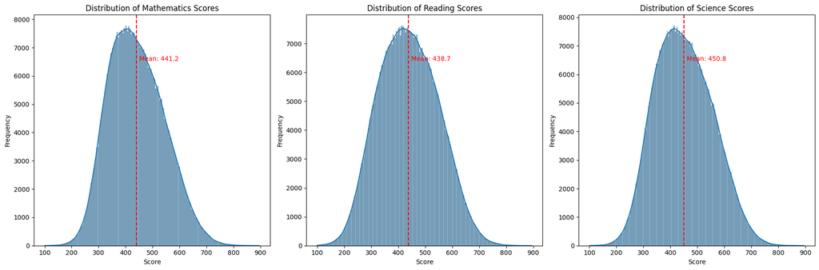

```python
def plot_performance_distributions(df):
    """Plot histograms of PISA performance scores"""
    performance_vars = ['PV1MATH', 'PV1READ', 'PV1SCIE']
    titles = ['Mathematics', 'Reading', 'Science']

    fig, axes = plt.subplots(1, 3, figsize=(18, 6))

    for i, (var, title) in enumerate(zip(performance_vars, titles)):
        sns.histplot(df[var], kde=True, ax=axes[i])
        axes[i].set_title(f'Distribution of {title} Scores')
        axes[i].set_xlabel('Score')
        axes[i].set_ylabel('Frequency')

        # Add mean line
        mean_val = df[var].mean()
        axes[i].axvline(mean_val, color='red', linestyle='--')
        axes[i].text(mean_val + 10, 0.8 * axes[i].get_ylim()[1],
                    f'Mean: {mean_val:.1f}', color='red')

    plt.tight_layout()
    plt.savefig('outputs/plots/performance_distributions.png')
    plt.show()

plot_performance_distributions(student_df)
```

### Question: How is the Economic, Social and Cultural Status (ESCS) index distributed among students?

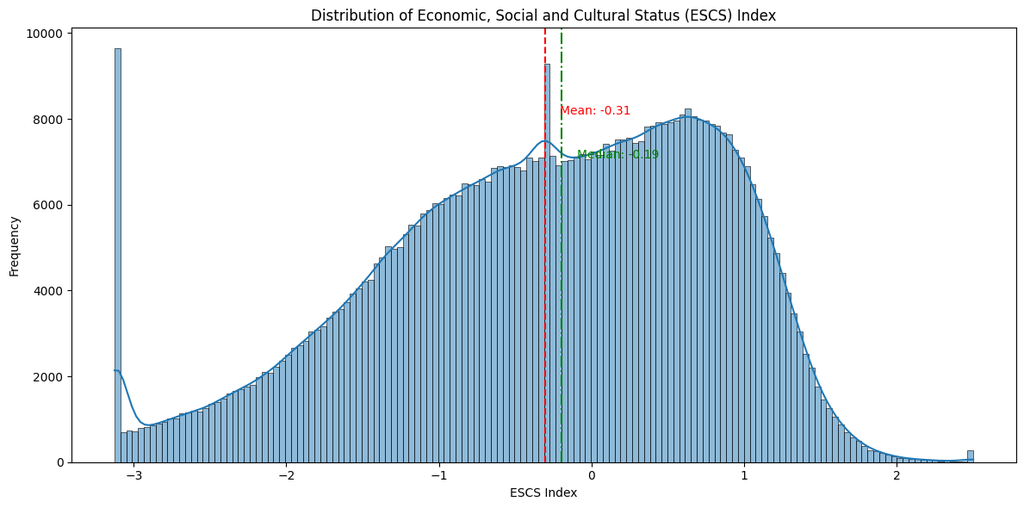

```python
def plot_escs_distribution(df):
    """Plot histogram of ESCS index"""
    plt.figure(figsize=(12, 6))

    sns.histplot(df['ESCS'], kde=True)
    plt.title('Distribution of Economic, Social and Cultural Status (ESCS) Index')
    plt.xlabel('ESCS Index')
    plt.ylabel('Frequency')

    # Add mean and median lines
    mean_val = df['ESCS'].mean()
    median_val = df['ESCS'].median()

    plt.axvline(mean_val, color='red', linestyle='--')
    plt.axvline(median_val, color='green', linestyle='-.')

    plt.text(mean_val + 0.1, 0.8 * plt.ylim()[1], f'Mean: {mean_val:.2f}', color='red')
    plt.text(median_val + 0.1, 0.7 * plt.ylim()[1], f'Median: {median_val:.2f}', color='green')

    plt.tight_layout()
    plt.savefig('outputs/plots/escs_distribution.png')
    plt.show()

plot_escs_distribution(student_df)
```

### Question: What is the gender distribution in the dataset?

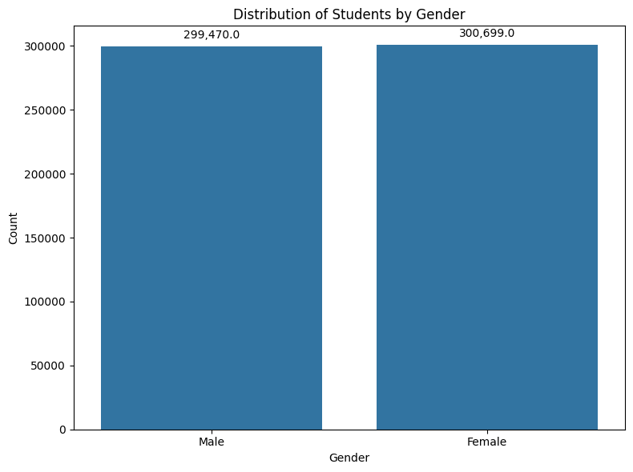

```python
# Create gender column
student_df['gender'] = student_df['ST004D01T'].map({1: 'Male', 2: 'Female'})

def plot_gender_distribution(df):
    """Plot count of students by gender"""
    plt.figure(figsize=(8, 6))

    sns.countplot(x='gender', data=df)
    plt.title('Distribution of Students by Gender')
    plt.xlabel('Gender')
    plt.ylabel('Count')

    for p in plt.gca().patches:
        plt.gca().annotate(f'{p.get_height():,}',
                          (p.get_x() + p.get_width() / 2., p.get_height()),
                          ha = 'center', va = 'center',
                          xytext = (0, 10), textcoords = 'offset points')

    plt.tight_layout()
    plt.savefig('outputs/plots/gender_distribution.png')
    plt.show()

plot_gender_distribution(student_df)
```

### Observations:

- The gender distribution in the dataset is well-balanced, with nearly equal numbers of male and female students.
- This balanced distribution helps ensure that gender-based comparisons are statistically reliable.
- The slight differences in counts are not significant and likely reflect the natural variation in the populations sampled.
- Having a balanced gender representation allows for robust analysis of gender gaps in performance across different subjects.

### Question: Which countries have the highest mathematics performance?

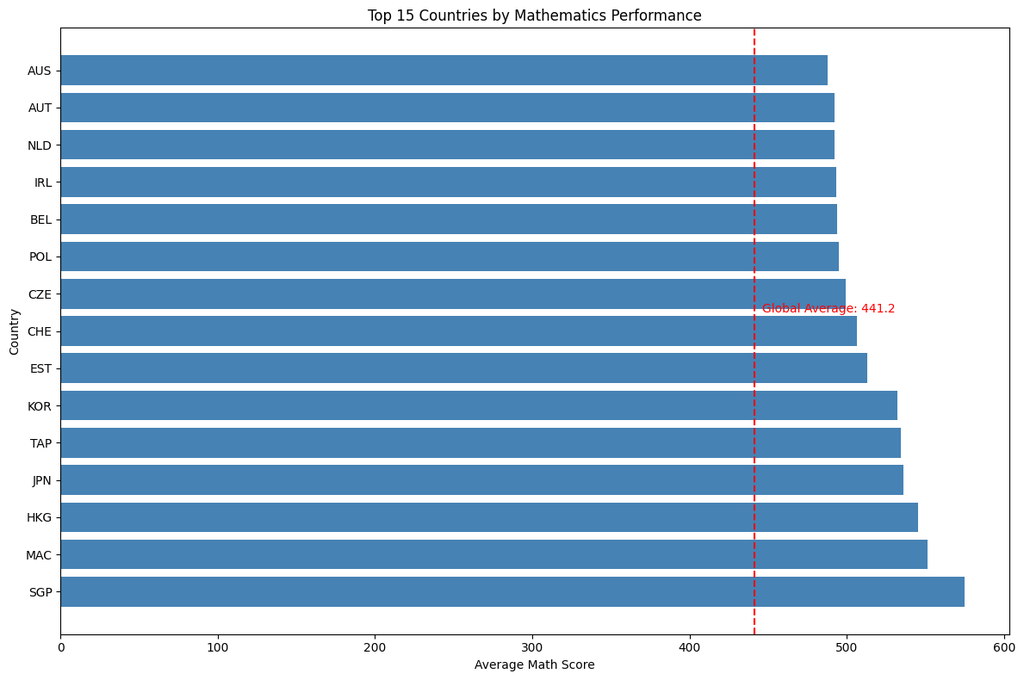

```python
def plot_top_countries_math(df, top_n=15):
    """Plot bar chart of top countries by math performance"""
    # Calculate mean math score by country
    country_math = df.groupby('CNT')['PV1MATH'].mean().sort_values(ascending=False)

    # Select only the top n countries
    top_countries = country_math.head(top_n)

    # Create figure with specific size
    plt.figure(figsize=(12, 8))

    # Use matplotlib's barh for horizontal bar chart instead of seaborn
    plt.barh(y=range(len(top_countries)), width=top_countries.values, color='steelblue')

    # Set y-ticks to be the country codes
    plt.yticks(range(len(top_countries)), top_countries.index)

    plt.title(f'Top {top_n} Countries by Mathematics Performance')
    plt.xlabel('Average Math Score')
    plt.ylabel('Country')

    # Add global average line
    global_avg = df['PV1MATH'].mean()
    plt.axvline(global_avg, color='red', linestyle='--')
    plt.text(global_avg + 5, len(top_countries)/2, f'Global Average: {global_avg:.1f}', color='red')

    plt.tight_layout()
    plt.savefig('outputs/plots/top_countries_math.png')
    plt.show()

# Execute the function
plot_top_countries_math(student_df)
```

### Discuss the distribution(s) of your variable(s) of interest. Were there any unusual points? Did you need to perform any transformations?

The ESCS index shows a slightly negative skew, with a longer tail toward disadvantaged backgrounds. This reflects global socioeconomic inequality, with more students coming from disadvantaged than advantaged backgrounds. No transformation was necessary for this analysis, as the negative skew is not severe enough to violate assumptions for our planned analyses.

The gender distribution is remarkably balanced, which is ideal for comparative analyses. No transformation was needed here.

Country-level mathematics performance reveals a clear pattern of East Asian dominance, with a substantial gap between top performers and the global average. These performance differences are substantive findings rather than unusual data points requiring transformation.

## Bivariate Exploration

In this section, I'll investigate relationships between pairs of variables in the PISA dataset, focusing on how performance metrics relate to demographic and socioeconomic factors.

### Question: What is the relationship between socioeconomic status (ESCS) and mathematics performance?

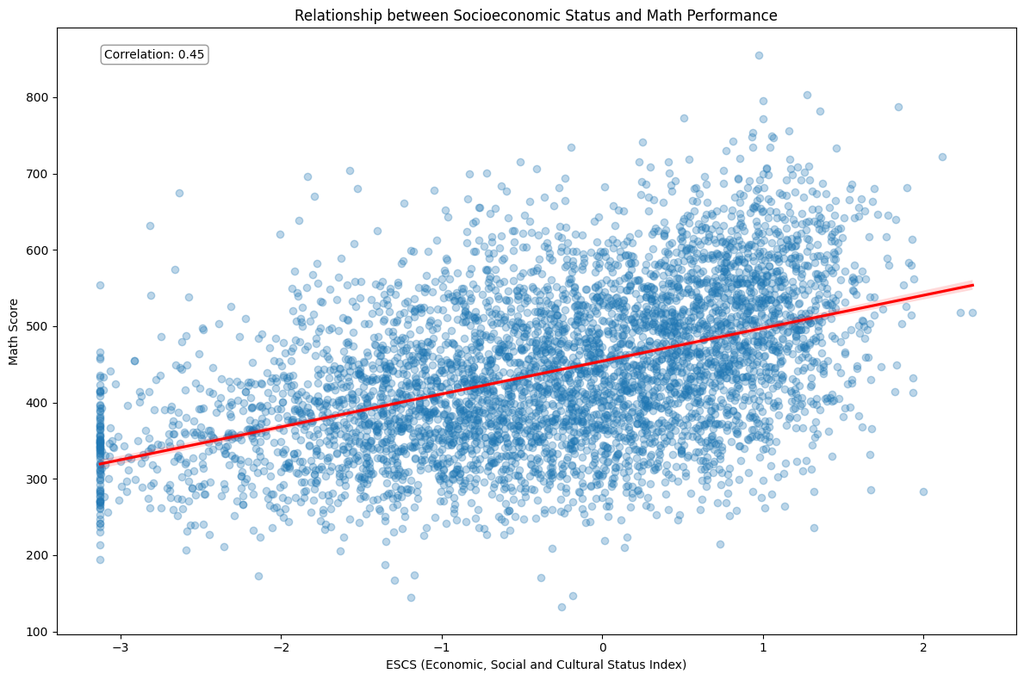

```python
def plot_escs_math_relationship(df, sample_size=5000):
    """Plot scatter plot of ESCS vs Math performance"""
    # Take a random sample to make plotting faster if dataset is large
    if len(df) > sample_size:
        sample_df = df.sample(sample_size, random_state=42)
    else:
        sample_df = df

    plt.figure(figsize=(12, 8))

    sns.regplot(x='ESCS', y='PV1MATH', data=sample_df,
                scatter_kws={'alpha': 0.3}, line_kws={'color': 'red'})

    plt.title('Relationship between Socioeconomic Status and Math Performance')
    plt.xlabel('ESCS (Economic, Social and Cultural Status Index)')
    plt.ylabel('Math Score')

    # Add correlation coefficient
    corr = df['ESCS'].corr(df['PV1MATH'])
    plt.annotate(f'Correlation: {corr:.2f}', xy=(0.05, 0.95), xycoords='axes fraction',
                bbox=dict(boxstyle="round,pad=0.3", fc="white", ec="gray", alpha=0.8))

    plt.tight_layout()
    plt.savefig('outputs/plots/escs_math_relationship.png')
    plt.show()

# Execute the function
plot_escs_math_relationship(student_df)
```